# Search Engine Optimzation for airline

Team 7: Abby, Delara, Dongwoo, Georg, Marta, Victoria

1/8/2019

## Abstract

This project was done by the team to analyze a dataset provided by a media solutions provider from their client airline company. The dataset is on search engine marketing data in a week in year 2007. The dataset contains different search keywords, publisher(search engine), number of searches conducted (impressions), clicks generated, number of bookings, revenue, and cost associated with the search keywords. The goal of the project is to analyze the dataset and to provide a solution to optimize the search engine marketing strategy of the airline. The team suggests two different approaches to optimize the airline’s search engine market strategy. First, is to save costs by removing unnecessary keywords, second is to suggesting a method to create new keywords using the keyword length.

## Descriptive Analysis

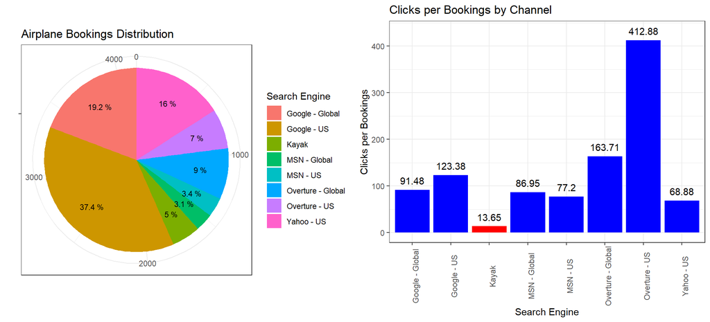

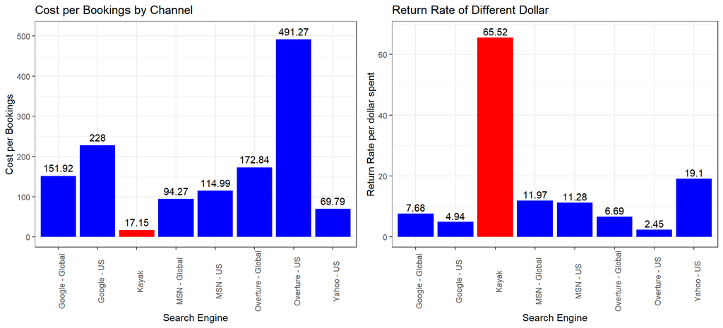

When looking at the different channels used by customers to book their plane tickets, Google has the largest volume in terms of number of bookings. Combining the global and US bookings, Google constitutes over 50% of the total number of online bookings during this period. However, when looking at the efficiency of marketing Kayak, a website for aggregating travelers and leading to the airline website, was the most efficient among the channels, bringing the highest return rate on every dollar spent. Among the different channels, Overture both global and US were the least performing channel which results in high marketing cost to lead to booking and the volume only constitutes 16%.

## Approach 1: Cost reduction

The first approach is to reduce cost by removing unnecessary high cost keywords. When looking at the keywords, there are total of 4097 out of 4462 keywords that does not lead to sales. However, removing all the keywords that does not lead to sales may remove the opportunity for future sales. Thus, it is necessary to keep keywords with high potential that leads traffic to the airline’s website whereas to remove keywords that brings low traffic to save cost. When comparing number of searches (impression) converted to traffic(clicks) rate, most keywords are in the lower end, with a decreasing exponential relationship. Keywords with conversion rates lower than 25% are considered to be low potential keywords. Thus, it is recommended to remove the keywords.

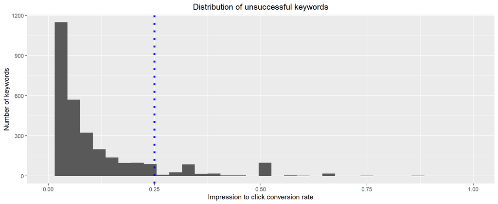

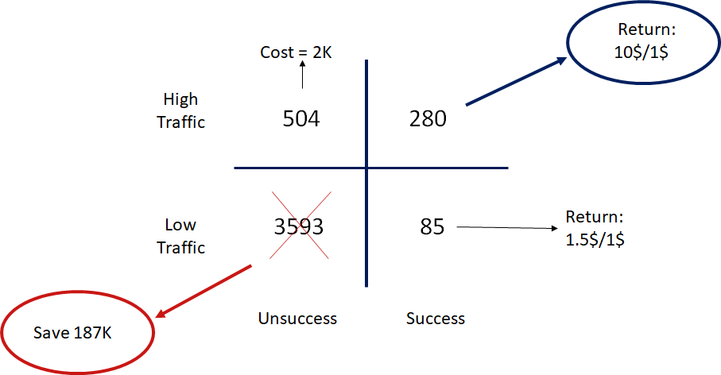

Among the unsuccessful keywords, it is highly recommended to remove the low potential 3593 keywords and keep the high potential 504 keywords. By doing so the airline can save $186,903 on its SEM budget. Additionally, the high potential keywords can be maintained even though it doesn’t generate any revenue, the cost of maintaining such keywords cost $2,173 and expect to bring revenue in the future. For the low booking to click ratio keywords still generate revenue in the searches. Thus, it is up to the company’s decision whether to maintain the keywords.

# Approach2: Optimizing keyword length

The second approach is to optimize the keyword length by comparing profit margin against keyword length. Shorter keywords tend to have higher revenue however, shorter keywords are highly competitive, making the keyword expensive, decreasing the profit margin. On the other hand, longer keywords are more specific, lower in price but also rarely searched.

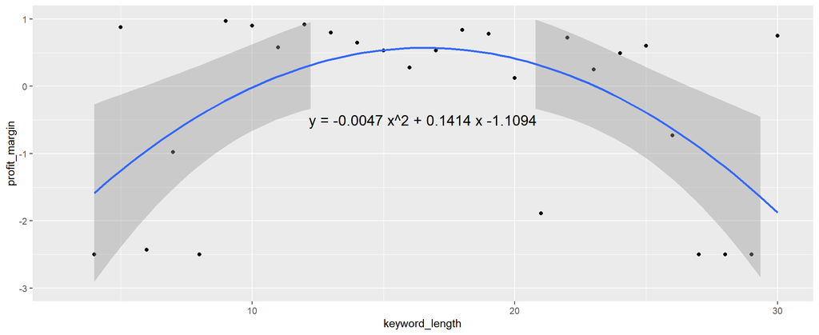

The profit margin to keyword length increases as the keyword length increases and it reaches its highest at keyword length of 16~17 letters. After 17 letters the profit margin decrease as the keyword length increases. Thus, when creating new keywords, it is important to keep the keyword length in this region.

## Conculsion

In conclusion search engine marketing requires constant modification to optimize. Two different approaches are suggested to reach the goal. One is to remove unsuccessful keywords that does not bring traffic or revenue to the airline company to reduce any unnecessary cost. Second is when creating new keywords, it is recommended to create keyword lengths around 17 letters, since 17 letter keywords give highest margin.